# Lösungen

## Lösungen zu den Aufgaben

#### Aufgabe

1. Gibt es einen Zusammenhang zwischen “Rauchen” und “Gesundheit”? Berechnen Sie das Odds Ratio von Gesundheit (zu Krankheit) von Nichtrauchern (im Verhältnis zu Rauchern!) in diesen fiktiven Daten.

#### Lösung

   ```
   z1 <- 1321
   z2 <- 173
   z3 <- 1619
   z4 <- 24
   Chance_Raucher_gesund <- (z1/z2)
   Chance_NRaucher_gesund <- (z3/z4)
   OR <- Chance_NRaucher_gesund / Chance_Raucher_gesund

   OR
   ```

   ```
   ## [1] 8.834437
   ```

#### Aufgabe

2. Werten Sie die Häufigkeiten (der Stufen) folgender Variablen aus wie unten beschrieben.

   Datensatz: `mtcars`.

   Variablen:
   - `am`
   - `cyl`
   - `vs`
   1. Erstellen Sie für jede der genannten Variablen eine univariate Häufigkeitsanalyse (also nur eine Variable).
   2. Erstellen Sie dann für die ersten beiden genannten Variablen eine gemeinsame Häufigkeitsanalyse (bivariat).
   3. Erstellen Sie dann für alle genannten Variablen eine gemeinsame Häufigkeitsanalyse.
   4. Wie viele Gruppen (also Häufigkeitswerte) ergeben sich (theoretisch) in der letzten Auswertung?

#### Lösung

   ```
   library("tidyverse")
   data("mtcars")
   ```

   1. univariate Häufigkeitsanalyse

   ```
   mtcars %>%
     group_by(am) %>%
     summarise(zeilen_n = n())
   ```

   ```
   ## # A tibble: 2 × 2
   ##      am zeilen_n
   ##   <dbl>    <int>
   ## 1     0       19
   ## 2     1       13
   ```

   Der Befehle `n()` gibt die Anzahl der Zeilen (Reihen) zurück. Da in einem Dataframe alle Zeilen gleich lang sind, brauchen wir keine Spalte anzugeben.

   Alternativ könnte man auch schreiben:

   ```
   mtcars %>%
     count(am)
   ```

   ```
   ##   am  n
   ## 1  0 19
   ## 2  1 13
   ```

   Das ist haargenau der gleiche Effekt wie die vorherige Syntax.

   Üblich ist auch, eine Kontingenztabelle so darzustellen:
   2. gemeinsame Häufigkeitsanalyse (bivariat)

   ```
   mtcars %>%
     count(am, cyl)
   ```

   ```
   ##   am cyl  n
   ## 1  0   4  3
   ## 2  0   6  4
   ## 3  0   8 12
   ## 4  1   4  8
   ## 5  1   6  3
   ## 6  1   8  2
   ```

   ```
   table(mtcars$am, mtcars$cyl)
   ```

   ```
   ##
   ##      4  6  8
   ##   0  3  4 12
   ##   1  8  3  2
   ```

   Wir sehen, dass wir $2\cdot3=6$ Gruppen haben, in denen sich die $n=32$ Beobachtungen aufteilen.
   3. Häufigkeitsanalyse mit 3 Variablen

   ```
   mtcars %>%
     count(am, cyl, vs)
   ```

   ```
   ##   am cyl vs  n
   ## 1  0   4  1  3
   ## 2  0   6  1  4
   ## 3  0   8  0 12
   ## 4  1   4  0  1
   ## 5  1   4  1  7
   ##  [ reached 'max' / getOption("max.print") -- omitted 2 rows ]
   ```

   Das sind drei Variablen mit $2 \cdot 3 \cdot 2 = 12$ Gruppen.

   Da einige der 12 Gruppen in den Daten nicht vorkommen, sind sie in der Auszählung der Häufigkeiten nicht aufgenommen; in den Daten gibt es nur 7 der 12 Gruppen.

#### Aufgabe

3. Betrachten Sie die Balkendiagramme. Welche Balkendiagramm zeigt den stärksten Zusammenhang?

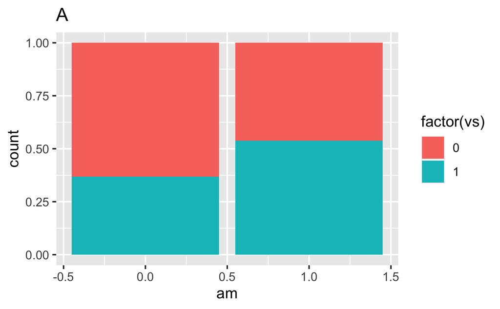

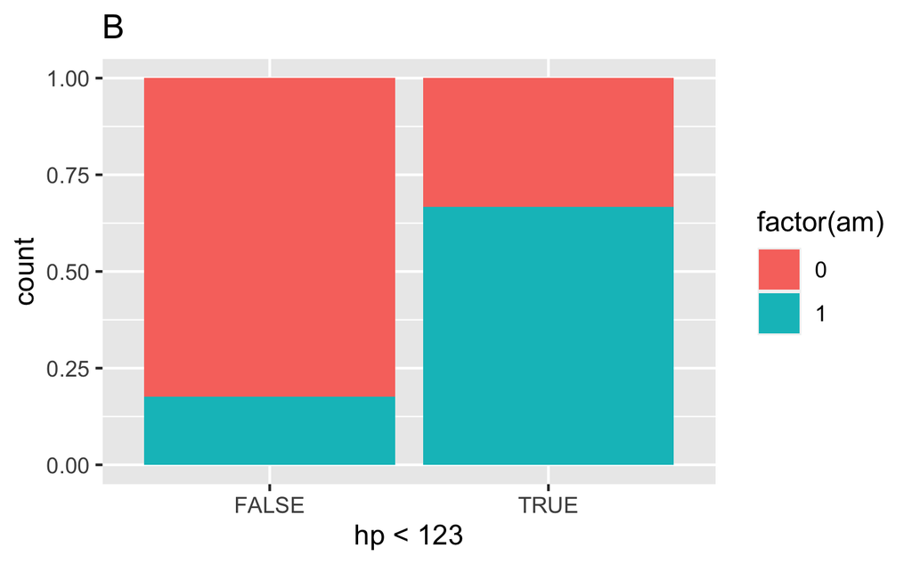

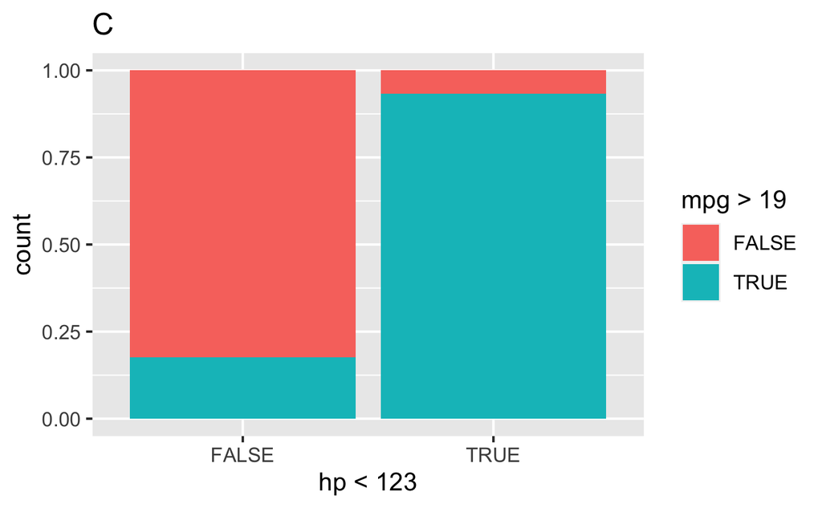

   1. A
   2. B
   3. C
   4. keine Antwort möglich

#### Lösung

   1. Falsch
   2. Falsch
   3. Wahr
   4. Falsch

#### Aufgabe

4. Viele Quellen berichten Klimadaten unserer Erde, z.B. auch [National Aeronautics and Space Administration - Goddard Institute for Space Studies](https://data.giss.nasa.gov/gistemp/).

   Von dieser Quelle beziehen wir [diesen Datensatz](https://data.giss.nasa.gov/gistemp/tabledata_v4/GLB.Ts+dSST.csv).

   Die Datensatz sind auf der Webseite wie folgt beschrieben:

   *Tables of Global and Hemispheric Monthly Means and Zonal Annual Means*

   Combined Land-Surface Air and Sea-Surface Water Temperature Anomalies (Land-Ocean Temperature Index, L-OTI)

   The following are plain-text files in tabular format of temperature anomalies, i.e. *deviations from the corresponding 1951-1980 means*.

   > Global-mean monthly, seasonal, and annual means, 1880-present, updated through most recent month: TXT, CSV

   Starten Sie zunächst das R-Paket `tidyverse` falls noch nicht geschehen.

   ```
   library(tidyverse)
   ```

   Importieren Sie dann die Daten:

   ```
   data_path <- "https://data.giss.nasa.gov/gistemp/tabledata_v4/GLB.Ts+dSST.csv"
   d <- read_csv(data_path, skip = 1)
   ```

   Wir lassen die 1. Zeile des Datensatzes aus (Argument `skip`), da dort *Metadaten* stehen, also keine Daten, sondern Informationen (Daten) zu den eigentlichen Daten.

   **Aufgabe**

   Berechnen Sie die folgende Statistiken pro Dekade:
   - Mittelwert der Temperatur im Januar
   - SD der Temperatur im Januar

   Hinweise:
   - Sie müssen zuerst die Dekade als neue Spalte berechnen.

#### Lösung

   Dekade berechnen:

   ```
   d <-
     d %>%
     mutate(decade = round(Year/10))
   ```

   Statistiken pro Dekade:

   ```
   d_summarized <-
     d %>%
     group_by(decade) %>%
     summarise(temp_mean = mean(Jan),
               temp_sd = sd(Jan))

   d_summarized
   ```

   | decade | temp_mean | temp_sd |
   | --- | --- | --- |
   | 188 | −0.19 | 0.24 |
   | 189 | −0.43 | 0.22 |
   | 190 | −0.26 | 0.16 |
   | 191 | −0.39 | 0.22 |
   | 192 | −0.28 | 0.15 |
   | 193 | −0.14 | 0.21 |
   | 194 | 0.03 | 0.21 |
   | 195 | −0.05 | 0.18 |
   | 196 | 0.03 | 0.15 |
   | 197 | −0.07 | 0.17 |
   | 198 | 0.21 | 0.19 |
   | 199 | 0.36 | 0.13 |
   | 200 | 0.52 | 0.19 |
   | 201 | 0.64 | 0.20 |
   | 202 | 0.96 | 0.14 |

   Zur Veranschaulichung visualisieren wir die Ergebnisse:

[figure not shown]

#### Aufgabe

5. Viele Quellen berichten Klimadaten unserer Erde, z.B. auch [National Aeronautics and Space Administration - Goddard Institute for Space Studies](https://data.giss.nasa.gov/gistemp/).

   Von dieser Quelle beziehen wir [diesen Datensatz](https://data.giss.nasa.gov/gistemp/tabledata_v4/GLB.Ts+dSST.csv).

   Die Datensatz sind auf der Webseite wie folgt beschrieben:

   *Tables of Global and Hemispheric Monthly Means and Zonal Annual Means*

   Combined Land-Surface Air and Sea-Surface Water Temperature Anomalies (Land-Ocean Temperature Index, L-OTI)

   The following are plain-text files in tabular format of temperature anomalies, i.e. *deviations from the corresponding 1951-1980 means*.

   > Global-mean monthly, seasonal, and annual means, 1880-present, updated through most recent month: TXT, CSV

   Starten Sie zunächst das R-Paket `tidyverse` falls noch nicht geschehen.

   ```
   library(tidyverse)
   ```

   Importieren Sie dann die Daten:

   ```
   data_path <- "https://data.giss.nasa.gov/gistemp/tabledata_v4/GLB.Ts+dSST.csv"
   d <- read_csv(data_path, skip = 1)
   ```

   Wir lassen die 1. Zeile des Datensatzes aus (Argument `skip`), da dort *Metadaten* stehen, also keine Daten, sondern Informationen (Daten) zu den eigentlichen Daten.

   **Aufgaben**
   - Berechnen Sie die die Korelation der Temperatur von Januar und Februar
   - Berechnen Sie die die Korelation der Temperatur von Januar und Februar pro Dekade

   Hinweise:
   - Sie müssen zuerst die Dekade als neue Spalte berechnen.

#### Lösung

   Dekade berechnen:

   ```
   d <-
     d %>%
     mutate(decade = round(Year/10))
   ```

   Korrelation:

   ```
   d %>%
     summarise(temp_cor = cor(Jan, Feb))
   ```

   ```
   ## # A tibble: 1 × 1
   ##   temp_cor
   ##      <dbl>
   ## 1    0.940
   ```

   Korrelation pro Dekade:

   ```
   d_summarized <-
     d %>%
     group_by(decade) %>%
     summarise(temp_cor = cor(Jan, Feb))
   ```

   | decade | temp_cor |
   | --- | --- |
   | 188 | 0.88 |
   | 189 | 0.79 |
   | 190 | 0.52 |
   | 191 | 0.84 |
   | 192 | 0.82 |
   | 193 | 0.72 |
   | 194 | 0.50 |
   | 195 | 0.78 |
   | 196 | 0.56 |
   | 197 | 0.79 |
   | 198 | 0.80 |
   | 199 | 0.54 |
   | 200 | 0.57 |
   | 201 | 0.67 |
   | 202 | 0.95 |

[figure not shown]

   Die Korrelation der Temperaturen und damit die Ähnlichkeit der Muster hat im Laufe der Dekaden immer mal wieder geschwankt.

#### Aufgabe

6. Viele Quellen berichten Klimadaten unserer Erde, z.B. auch [National Aeronautics and Space Administration - Goddard Institute for Space Studies](https://data.giss.nasa.gov/gistemp/).

   Von dieser Quelle beziehen wir [diesen Datensatz](https://data.giss.nasa.gov/gistemp/tabledata_v4/GLB.Ts+dSST.csv).

   Die Datensatz sind auf der Webseite wie folgt beschrieben:

   *Tables of Global and Hemispheric Monthly Means and Zonal Annual Means*

   Combined Land-Surface Air and Sea-Surface Water Temperature Anomalies (Land-Ocean Temperature Index, L-OTI)

   The following are plain-text files in tabular format of temperature anomalies, i.e. *deviations from the corresponding 1951-1980 means*.

   > Global-mean monthly, seasonal, and annual means, 1880-present, updated through most recent month: TXT, CSV

   Starten Sie zunächst das R-Paket `tidyverse` falls noch nicht geschehen.

   ```
   library(tidyverse)
   ```

   Importieren Sie dann die Daten:

   ```
   data_path <- "https://data.giss.nasa.gov/gistemp/tabledata_v4/GLB.Ts+dSST.csv"
   d <- read_csv(data_path, skip = 1)
   ```

   Wir lassen die 1. Zeile des Datensatzes aus (Argument `skip`), da dort *Metadaten* stehen, also keine Daten, sondern Informationen (Daten) zu den eigentlichen Daten.

   **Aufgaben**
   - Erstellen Sie für jeden Januar eine Variable (`temp_is_above`), die ausgibt, ob die Temperatur über oder unter dem Durchschnitt liegt (d.h. eine negative oder positive Abweichung ist). Nutzen Sie als Ausprägungen die Werte “yes” und “no”.
   - Erstellen Sie dann eine Variable, die das Jahrhundert angibt (19. JH. vs. 20 JH).
   - Zählen Sie dann wie oft `temp_is_above` “yes” aufweist pro Jahrhundert (“erhöhter Temperatur”).
   - Berechnen Sie das Odds Ratio (Chancenverhältnis) von erhöhter Temperatur (vs. nicht erhöhter Temperatur) zwischen dem 19. und dem 20. Jahrhundert.

   Für “Wenn-Dann-Abfragen” eignet sich folgender R-Befehl (als “Pseudocode” dargestellt):

   ```
   d %>%
     mutate(neue_spalte = case_when(
       erste_bedingung_bzw_wenn_teil ~ dann_teil1,
       zweite_bedingung_bzw_zweiter_wenn_teil ~ dann_teil2
     ))
   ```

#### Lösung

   `temp_is_above` erstellen:

   ```
   d <-
     d %>%
     mutate(temp_is_above = case_when(
       Jan > 0 ~ "yes",
       Jan <= 0 ~ "no"
     ))
   ```

   Jahrhundert berechnen:

   ```
   d <-
     d %>%
     mutate(century = case_when(
       Year < 1900 ~ "19th",
       Year >= 1900 ~ "20th"
     ))
   ```

   Erhöhte Werte der Januar-Temperatur pro Jahrhundert berechnen:

   ```
   d_summarized <-
   d %>%
     group_by(century) %>%
     count(temp_is_above)

   d_summarized
   ```

   ```
   ## # A tibble: 4 × 3
   ## # Groups:   century [2]
   ##   century temp_is_above     n
   ##   <chr>   <chr>         <int>
   ## 1 19th    no               19
   ## 2 19th    yes               1
   ## 3 20th    no               56
   ## 4 20th    yes              67
   ```

   Der Befehl `count()` zählt aus, wie häufig die Ausprägungen der angegebenen Variablen `X` sind, m.a.W. er gibt die Verteilung von `X` wieder.

   Es macht vermutlich Sinn, noch die Anteile (relative Häufigkeiten) zu den absoluten Häufigkeiten zu ergänzen:

   ```
   d_summarized %>%
     mutate(prop = n / sum(n))
   ```

   ```
   ## # A tibble: 4 × 4
   ## # Groups:   century [2]
   ##   century temp_is_above     n  prop
   ##   <chr>   <chr>         <int> <dbl>
   ## 1 19th    no               19 0.95
   ## 2 19th    yes               1 0.05
   ## 3 20th    no               56 0.455
   ## 4 20th    yes              67 0.545
   ```

   Odds Ratio berechnen:

   Wir bezeichnen mit `c19` (für “Chance 1”) das Verhältnis von erhöhter Temperatur zu nicht erhöhter Temperatur im 19. Jahrhundert.

   ```
   c19 <- 1 / 19
   ```

   ```
   c20 <- 56 / 67
   ```

   Das Verhältnis der beiden Chancen gibt das Chancenverhältnis (Odds Ratio, OR):

   ```
   c19 / c20
   ```

   ```
   ## [1] 0.06296992
   ```

   Genauso gut kann man das OR von `c20` zu `c19` ausrechnen, der Effekt bleibt identisch:

   ```
   c20 / c19
   ```

   ```
   ## [1] 15.8806
   ```

#### Aufgabe

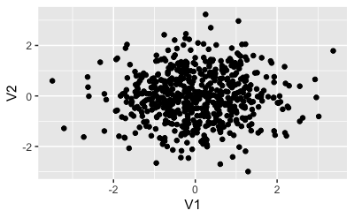

7. Welcher Korrelationswert (Pearson) beschreibt die Korrelation in den Daten am besten?
   1. $r = 1$
   2. $r = -1$
   3. $r = 0$
   4. $r = .8$
   5. $r = -.8$

#### Lösung

   C. Die Daten wurden aus unkorrelierten Populationen (jeweils normalverteilt) gezogen, also $\rho = 0$.

   Hinweis: Griechische Buchstaben werden hier verwendet, um Variablen aus Populationen zu beschreiben (Parameter), lateinische Buchstaben werden für Stichproben verwendet.
   1. Falsch
   2. Falsch
   3. Wahr
   4. Falsch
   5. Falsch

#### Lösung

   Die Korrelation in der zugehörigen (bivariaten) Population beträgt -0.9.

   In der *Stichprobe* kann der zugehörige Wert (etwas abweichen).

   Das ist genauso, wie wenn man sagt, dass der “mittlere deutsche Mann” 1,80m groß sei, aber wenn Sie eine Stichprobe ziehen, muss der Mittelwert ja auch nicht (notwendigerweise) exakt bei 1,80m lliegen.

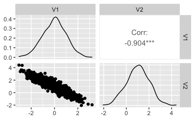